# Demographic effects on Crime

Doug Walton, DureSameen Awan, Erika Garces

May 4, 2016

# Effects of Demographics on Specific Crimes

## MOTIVATION

Crime is any act that causes harm to individual(s), communities, society or state. Crime is a topic that terrorizes yet fascinates many people including all our team members. Crime stories are showcased all over media and gain much attention. Popular crime topics include murder (homicide) or rape. Our team members background includes interests in psychology, dynamics of social change and criminology. All the team members are fascinated with exploring effects of demographics on crime.

Crime changes from state to state, from form to frequency. Why? What are the demographic factors that make people commit a crime? Will there be any interesting relationships between crimes and demographics?

## OVERVIEW

In this project, we explore the above questions using publically available data from various U.S. sources and associated R packages. In particular, we will explore whether homicide or rape seems associated with any identifiable demographic factors. This will give insight into the research possibilities for using these datasets with this kind of social science question. The question we will attempt to answer within this project is: Are demographics correlated with the prevalence of either homicide or rape? If yes, then which ones.

# GOAL

To identify key demographic factors that predict the prevalence of homicide or rape. Identify if these influences are better understood at national or state level. We will let the data guide us, our scope will be to cover all the states in USA.

Demographic factors we will explore and limit our analysis to are:

Effects of 1. Household type 2. Age 3. Gender 4. Race 5. Education 6. Income and 7. Population on homicide and rape across U.S. States.

# Approach

Our research followed two different approaches. The first is a historical approach to see how thing changed over time across nations under study. The second is a comparison between state-to-state and county-to-county to see effects of demographics on crime.

## Approach #1

Look at national data over time. In particular we will be exploring how demographic effects on crime within USA over time.

## Approach #2

looking at 2015 data for all U.S. states for all demographic data to fnd trends. Then doing a deeper dive of previous years for particular states.

we will be using the following libraries in our analysis:

```r
suppressMessages (library(dplyr))
library(tidyr)
library(ggplot2)
library(readr)
library(broom)
library(knitr)
```

## DATA COLLECTION NOTE:

Starting with tables derived from the 2012 Statistical Abstract of the United States http://www.census.gov/library/publications/2011/compendia/statab/131ed.html

1. us_national.csv is population by year from 1900 to 2015. initially derived from Section 1, Tables 1 & 2. Lagging zeros filled in on earlier years to make everything in consistent units (removed ’000s reduction). Added years 2010 to 2015 from PEPANNRES annual estimates of population (found through American Fact Finder.)

I then take selected chosen areas from different census tables to add to this national master.

A based table is constructed from the UC census table 12s0059.xls from the U.S. Statistical Abstract 2012, which covers 1960 to 2010, and then selected householder characteristics for 2011 to 2014 are added from the ACS filess and B11001, B11001A, B11001I to create 12s0059-households.csv. (Tables can be found using American Fact Finder)

### APPROACH 1: National Level

```r
# Starting with a base table US national population data by year from 1900
uspop <- read.csv("/Users/erikagafe/107Harvard-CrimeProject/us_national.csv")
uspop$year <- as.character(uspop$year)


# Add household data and select out key types that might we worth looking at
# years 1960 to 2014
UShousehold <- read.csv("/Users/erikagafe/107Harvard-CrimeProject/Sources/12s0059-households.csv")
UShousehold$Type.of.unit <- as.character(UShousehold$Type.of.unit)
UShousehold$Type.of.unit[3:9] <- c("Household_white","Household_black","Household_hispanic","fam_household","couple_household","male_household","fem_household")
UShousehold_s <- UShousehold %>% slice(1:9) %>% select(-X1960) # eliminate gap
cols <- UShousehold_s$Type.of.unit
UShousehold_s <- as.data.frame(t(UShousehold_s[,-1]))
colnames(UShousehold_s) <- cols
UShousehold_s <- add_rownames(UShousehold_s, "year")
# UShousehold$year <- as.factor(UShousehold$year)
usnat <- uspop %>% left_join(UShousehold_s, by = 'year')

# Add income data for age, sex, and major ethnic groups in 2009 dollars
# years 1947 to 2009
USincome <- read.csv("/Users/erikagafe/107Harvard-CrimeProject/Sources/12s0701-median-income-2009-dollars.csv")
USincome$X <- as.character(USincome$X)
cols <- USincome$X
USincome_s <- as.data.frame(t(USincome[,-1]))
colnames(USincome_s) <- cols
USincome_s <- add_rownames(USincome_s, "year")
usnat <- usnat %>% left_join(USincome_s, by = 'year')

# Educational attainment 1960 to 2010 for age, sex, major ethnicity
USedu <- read.csv("/Users/erikagafe/107Harvard-CrimeProject/Sources/12s0230-education.csv")
USedu$year <- as.character(USedu$year)
usnat <- usnat %>% left_join(USedu, by = 'year')

# Ppulation subgroups by ethnicity and sex 2000 to 2010
USbasic2010 <- read.csv("/Users/erikagafe/107Harvard-CrimeProject/Sources/US-EST00INT-ALLDATA.csv")
USbasic2010 <- USbasic2010 %>% filter(AGE != '999' & MONTH != '4')
USbasic2010 <- USbasic2010[,-1]

USbasic2010sum <- USbasic2010 %>% group_by(YEAR) %>% summarise(tot_male = sum(TOT_MALE), tot_female = sum(TOT_FEMALE), white_male_pop = sum(WA_MALE),white_female_pop = sum(WA_FEMALE),black_male_pop = sum(BA_MALE),black_female_pop = sum(BA_FEMALE),hisp_male_pop = sum(H_MALE),hisp_female_pop = sum(H_FEMALE))


USbasic2010sum <- rename(USbasic2010sum, year = YEAR)
USbasic2010sum$year <- paste0("X",USbasic2010sum$year)
usnat <- usnat %>% left_join(USbasic2010sum, by = 'year')

# Adding homicide and rape data 1960 to 2012
UScrime <- read.csv("/Users/erikagafe/107Harvard-CrimeProject/Sources/12s0306-tot_in_thousands_ofcrimetype1980-2009.csv")
UScrime<- UScrime %>% mutate (year1= year)
UScrime$year <- paste0("X",UScrime$year)
UScrime[2:6] <- UScrime[2:6] * 1000
usnat2 <- usnat %>% left_join(UScrime, by = 'year')
```

As can be seen in the tables and commentary above, while there is a considerable amount of data available, compiling a longitudinal view is challenging because the data was collected in differing ways over decades, with differing assumptions and labels. Some of the data is already based on approximations by US census bureau, and to join the tables into a continous data series for decades involves further assumptions about how closely one category is like another. At a macro-level, this may not matter much for initially finding productive opportunities for research, but it is something to be kept in mind for later verification.

# National rate of homocide and rape

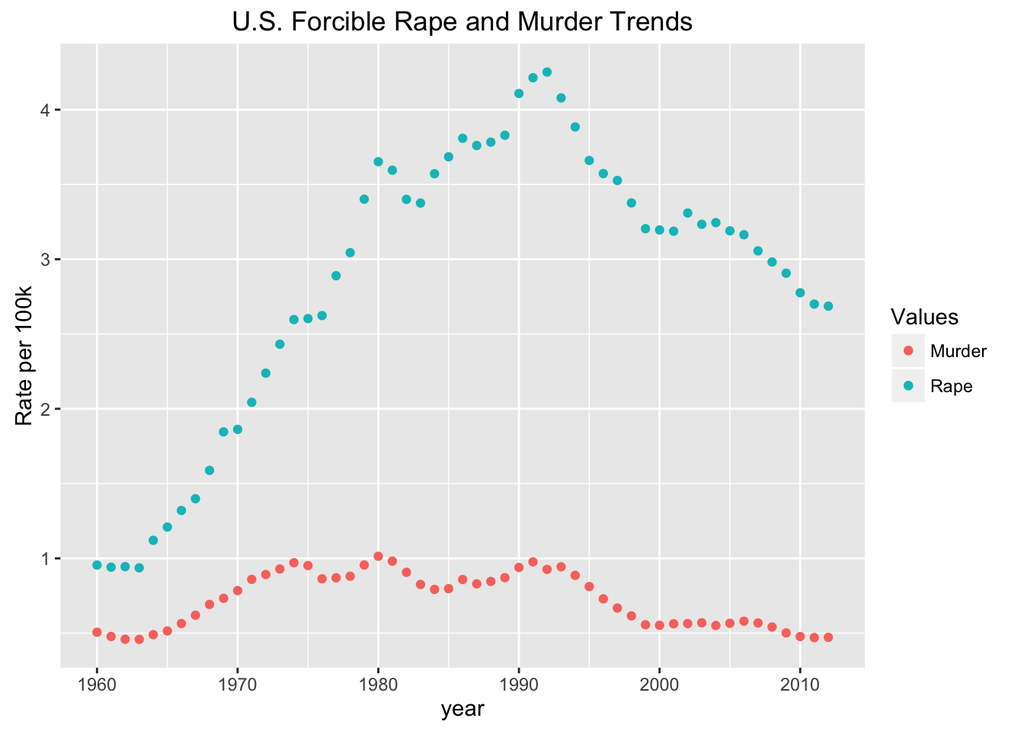

```r
rap_hom <- usnat2 %>% filter(year1 >= '1960' & year1 <= '2012')%>% mutate(murderpct = murder/residents*10000, rapepct = forcible_rape/residents*10000)

# Graph of murders and rape trend over the last few decade
rap_hom  %>% ggplot(aes(year1)) + geom_point(aes(y = murderpct, col = "Murder")) + geom_point(aes(y=rapepct, col="Rape")) + labs(title="U.S. Forcible Rape and Murder Trends", y = "Rate per 100k", col="Values", x="year")
```

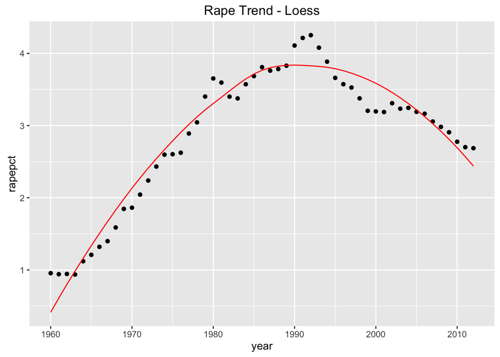

```r
# To take a close look at the rape trend
dat <- rap_hom %>% select(year, rapepct,murderpct)
dat$year1 <- seq(1960,2012)

# fitting line to rape data using loess to see about the trend
mod <- loess(rapepct~year1, degree=2, span = 1, data=dat)
loess_fit <- augment(mod)

dat %>% ggplot(aes(year1)) + geom_point(aes(y=rapepct)) + geom_line(aes(x=year1, y=.fitted), data=loess_fit, color="red") + labs(title="Rape Trend - Loess", x ="year")
```

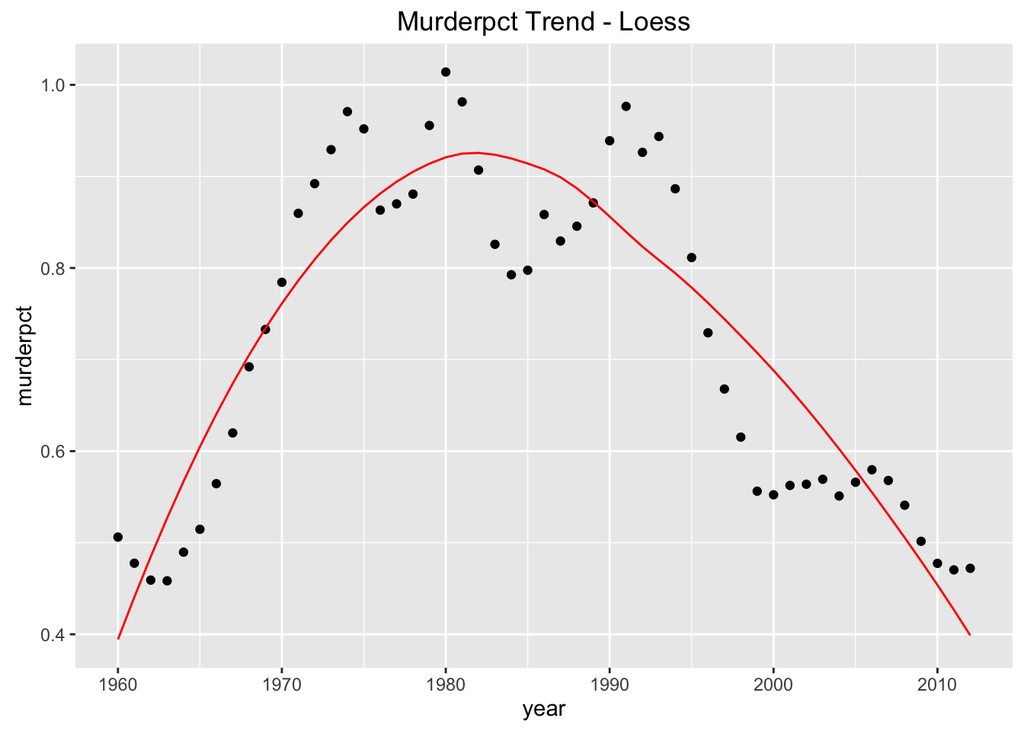

```r
# fitting line to murderpct data using loess to see about the trend
mod <- loess(murderpct~year1, degree=2, span = 1, data=dat)
loess_fit <- augment(mod)

dat %>% ggplot(aes(year1)) + geom_point(aes(y=murderpct)) + geom_line(aes(x=year1, y=.fitted), data=loess_fit, color="red") + labs(title="Murderpct Trend - Loess", x ="year")
```

#### 1. Household type

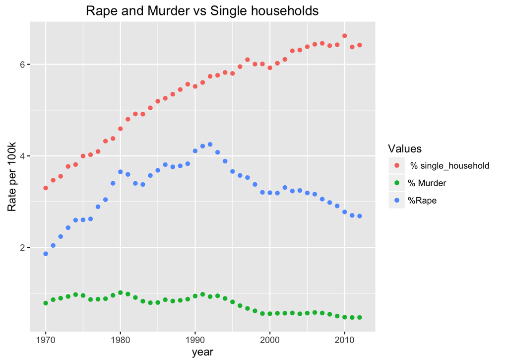

```r
#The graphs below only takes into account single households, male and female.
ushousehold <- rap_hom %>% mutate (single_householdpct =((male_household + fem_household)/residents)*100000)%>% mutate(housepct = (couple_household/residents)*100000)

#ushousehold%>%filter(year1>=1970)%>%ggplot(aes(year1)) +geom_point( aes(y=housepct, color = "%couples households")) + geom_point(aes(y=rapepct, color = "%Rape")) +geom_point( aes(y=murderpct, color = "% Murder"))  +labs(title="Rape and Murder vs Couple households", y = "Rate per 100k", col="Values", x="year")

ushousehold%>%filter(year1>=1970)%>%ggplot(aes(year1)) + geom_point( aes(y=single_householdpct, color = " % single_household"))+ geom_point(aes(y=rapepct, color = "%Rape")) +geom_point( aes(y=murderpct, color = "% Murder"))  +labs(title="Rape and Murder vs Single households", y = "Rate per 100k", col="Values", x="year")
```

```r
#ggplot(ushousehold, aes(x=single_householdpct, y=rapepct)) + geom_point( aes(color=year1 ,size=residents))+labs(title="U.S. Rape Trends in single household", y = "Rape percentage")

#ggplot(ushousehold, aes(x=year1, y=murderpct)) + geom_point( aes(single_householdpct)) +labs(title="U.S. Murder Trends in single household", y = "Murder percentage")

#The graphs below only takes into account couple households, male and female.
#ushousehold <- ushousehold %>% mutate(housepct = (couple_household/residents)*10000)

#ggplot(ushousehold, aes(x=housepct, y=rapepct)) + geom_point( aes(color=year1 , size=residents)) +labs(title="U.S. Rape Trends in Couple household", y = "Rape percentage")

#ggplot(ushousehold, aes(x=housepct, y=murderpct)) + geom_point( aes(color=year1 , size=residents)) +labs(title="U.S. Murder Trends in Couple household", y = "Murder percentage")
```

#### 2. Age (median age)

Data gotten from [US census Bureau](https://www.census.gov/prod/cen2010/briefs/c2010br-03.pdf)

```r
year1 <- seq(1960,2010, 10)
under18 <- c(24.0,25.7,25.6,28.1,34.3,35.9)
under44 <- c(36.5,39.9,43.2,40.9,35.3,34.8)
over65 <- c(26.4,22.0,18.6,19.6,20.6,20.3)
median <- c(29.5,28.1,30.0, 32.9,35.3,37.2)
hist_pop <- data.frame(year1,under18,under44,over65,median)
kable(hist_pop)
```

| year1 | under18 | under44 | over65 | median |
| --- | --- | --- | --- | --- |
| 1960 | 24.0 | 36.5 | 26.4 | 29.5 |
| 1970 | 25.7 | 39.9 | 22.0 | 28.1 |
| 1980 | 25.6 | 43.2 | 18.6 | 30.0 |
| 1990 | 28.1 | 40.9 | 19.6 | 32.9 |
| 2000 | 34.3 | 35.3 | 20.6 | 35.3 |
| 2010 | 35.9 | 34.8 | 20.3 | 37.2 |

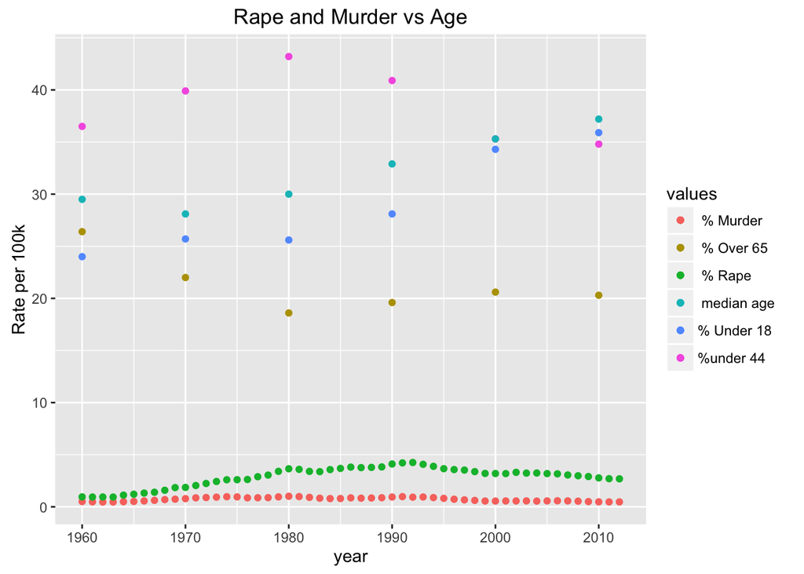

```r
## Plotting it against the rape curve
age<-ushousehold%>% left_join(hist_pop)
age%>%ggplot(aes(year1)) + geom_point(aes(y=under44, color = "%under 44"))  + geom_point(aes(y=under18, color = "% Under 18"))  +  geom_point(aes(y=over65, color = " % Over 65"))  +  geom_point(aes(y=median, color = " median age"))  +
geom_point(aes(y=murderpct, color = " % Murder"))+ geom_point(aes(y = rapepct,color=" % Rape ")) +labs(title="Rape and Murder vs Age", y = "Rate per 100k", x="year", col="values")
```

#### 3. Gender

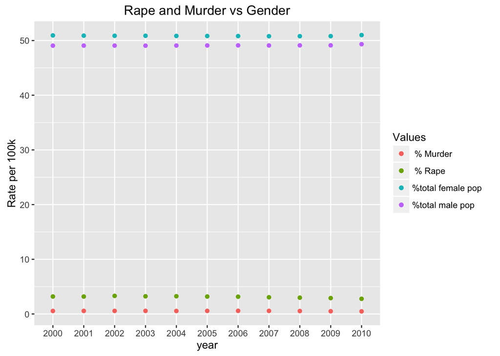

```r
#y<-ushousehold%>%select(tot_male, residents,year1)%>% mutate(tot_male = tot_male/residents*100)%>% filter(year1>=2000)%>%mutate(key="tot_male")
#x<-ushousehold%>%select(tot_female,residents,year1)%>% mutate(tot_female = tot_female/residents*100)%>% filter(year1>=2000)%>%mutate(key="tot_female")
#m<-ushousehold%>%filter(year1>=2000)%>%select(murderpct,rapepct,year1)

#xy<-full_join(y,x)
#xy<-full_join(xy,m)

#%>%filter(year1>=2000 & year1<=2010)
gender<-ushousehold%>%select(tot_male,tot_female,murderpct,rapepct,residents,year1)%>% mutate(tot_male = tot_male/residents*100)%>% mutate(tot_female = tot_female/residents*100)%>%filter(year1>=2000 & year1<=2010)
gender$year1 <- as.character(gender$year1)

gender%>%ggplot(aes(year1)) + geom_point(aes(y=tot_male, color = "%total male pop"))  + geom_point(aes(y=tot_female, color = "%total female pop"))  +
geom_point(aes(y=murderpct, color = " % Murder"))+ geom_point(aes(y = rapepct,color=" % Rape ")) +labs(title="Rape and Murder vs Gender", y = "Rate per 100k", x="year", col="Values")
```

```r
#ggplot(xy, aes(year1,total,group=key,color=key, col=key)) + geom_point(aes(y=murderpct))
#ggplot(xy, aes(year1,group=key,col=key))+ geom_point(aes(y=total))+  geom_point(aes(y=rapepct, color= 'Rape')) +labs(title="U.S. Gender Trends vs murder", y = "Rate per 100000", x= "year")

#ushousehold%>% mutate(total = tot_male/residents*10000)%>%filter(year1>=2000)%>%ggplot(aes(total, murderpct)) + geom_point(aes(color=year1, size=residents))+labs(title="U.S. Gender Trends vs murder", x = "Male Rate per 100000", y= "Murder percentage")

#ushousehold%>% mutate(total = tot_female/residents*10000)%>%filter(year1>=2000)%>%ggplot(aes(total, murderpct)) + geom_point(aes(color=year1, size=residents))+labs(title="U.S. Gender Trends vs murder", x = "Female Rate per 100000", y= "Murder percentage")


#ushousehold%>% mutate(total1 = tot_female/residents*10000)%>% mutate(total = tot_male/residents*10000)%>%filter(year1>=2000)%>%ggplot(aes(y=murderpct)) + geom_point(aes(x=total1, col="female"))+ geom_point(aes(x=total, col="male"))+labs(title="U.S. Gender Trends vs murder", x = "Rate per 100000", y= "Murder percentage")

#ushousehold%>% mutate(total1 = tot_female/residents*10000)%>% mutate(total = tot_male/residents*10000)%>%filter(year1>=2000)%>%ggplot(aes(y=rapepct)) + geom_point(aes(x=total1, col="female"))+ geom_point(aes(x=total, col="male"))+labs(title="U.S. Gender Trends vs Rape", x = "Rate per 100000", y= "Rape percentage")


# Graph of murders and rape trend over the last few decade
# ushousehold%>%filter(year1>=2000)%>% ggplot(aes(year1))+ geom_point(aes(y=murderpct, col="murder")) + geom_point(aes(y=tot_male, col="male")) + geom_point(aes(y=tot_female, col="female")) + labs(title="U.S. Murder Trends vs Gender", y = "Rate per 100000", x= "year", col="values")


# ushousehold  %>% ggplot(aes(year1, residents))+ geom_point(aes(y=forcible_rape, col="forcible_rape")) + geom_point(aes(y=tot_male, col="male")) +geom_point(aes(y=murder, col="murder")) + geom_point(aes(y=tot_female, col="female")) + labs(title="U.S. Rape Trends vs Gender", y = "Rate per 100000", x= "year", col="values")
```

#### 4. Race (a particular race is more prominent in crime areas)

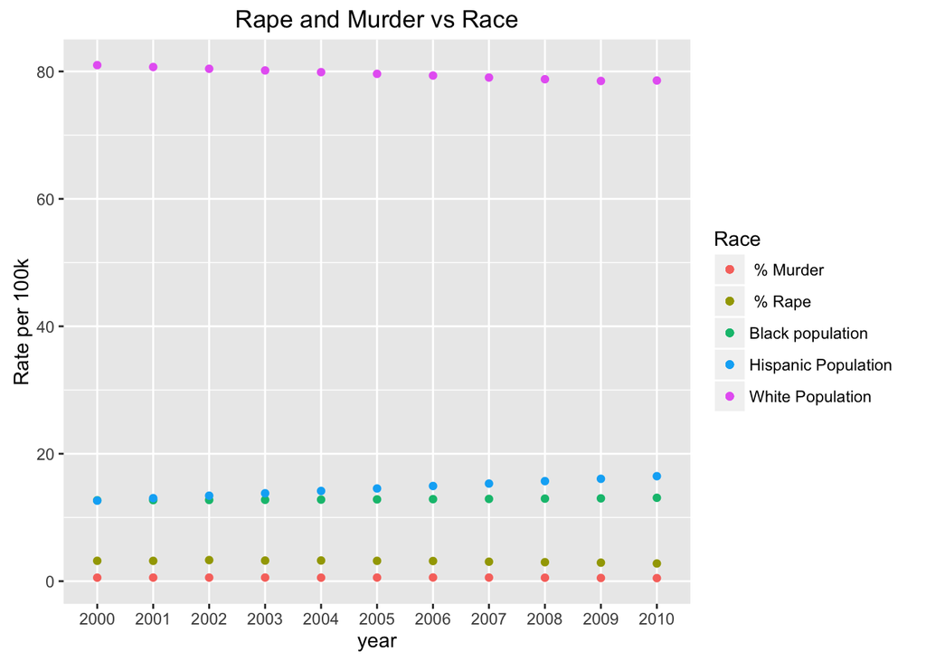

```r
race<-ushousehold%>%mutate(white_pop= ((white_male_pop+ white_female_pop)/residents*100)) %>%mutate(black_pop= (black_male_pop+ black_female_pop)/residents*100) %>%mutate(hisp_pop= (hisp_male_pop+ hisp_female_pop)/residents*100)


race<-race%>%filter(year1>=2000 & year1<=2010)
race$year1 <- as.character(race$year1)

race%>%ggplot(aes(year1)) + geom_point(aes(y=white_pop, col="White Population")) + geom_point(aes(y=black_pop, col="Black population")) + geom_point(aes(y=hisp_pop, col="Hispanic Population")) + geom_point(aes(y=murderpct, color = " % Murder"))+ geom_point(aes(y = rapepct,color=" % Rape "))+ labs(title="Rape and Murder vs Race", y="Rate per 100k", col="Race", x= "year")
```

#### 5. Education

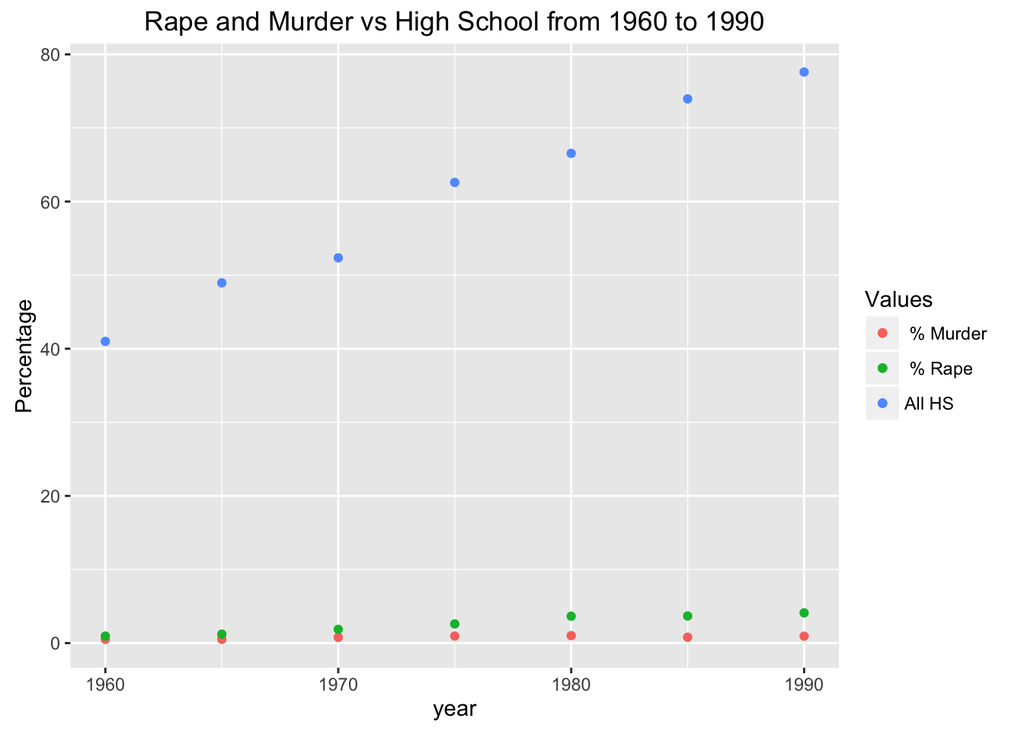

```r
Edu <- rap_hom%>%mutate(hs=(hs.all.male+ hs.all.female)/2)%>%mutate(coll=(col.all.male+ col.all.female)/2)%>%filter(coll!=is.nan(coll))

#Edu  %>% ggplot(aes(year1)) + geom_point(aes(y=hs.all.male, col="All Males HS")) + geom_point(aes(y=hs.all.female, col="All Females HS")) + geom_point(aes(y=col.all.male, col="All Males College")) + geom_point(aes(y=col.all.female, col="All Females College")) + labs(title="High School and College - All Males vs All Females", y="Percent Completion", col="Education", x= "year")


Edu%>% filter(year1>=1960 & year1<=1990)%>% ggplot(aes(year1)) + geom_point(aes(y=hs,  col='All HS')) +geom_point(aes(y=murderpct, color = " % Murder"))+ geom_point(aes(y = rapepct,color=" % Rape "))+ labs(title="Rape and Murder vs High School from 1960 to 1990", y="Percentage", col="Values", x= "year")
```

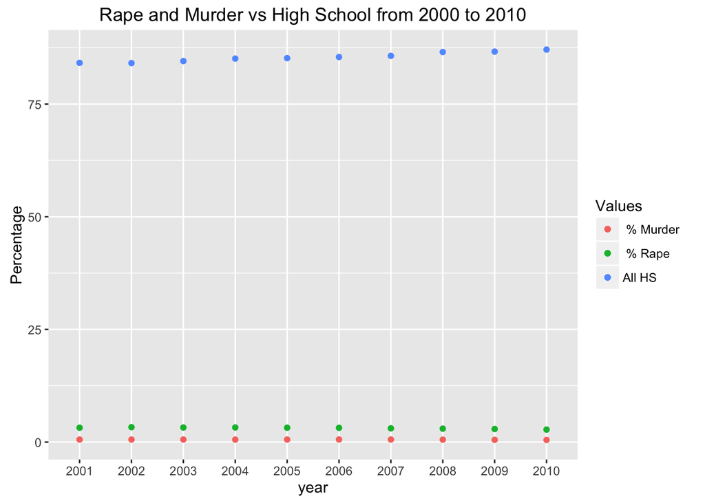

```r
Edu<-Edu%>% filter(year1>=2000 & year1<= 2010)
Edu$year1 <- as.character(Edu$year1)

Edu%>% ggplot(aes(year1)) + geom_point(aes(y=hs,  col='All HS')) +geom_point(aes(y=murderpct, color = " % Murder"))+ geom_point(aes(y = rapepct,color=" % Rape "))+ labs(title="Rape and Murder vs High School from 2000 to 2010", y="Percentage", col="Values", x= "year")
```

```r
#ggplot(Edu, aes(x=hs, y=murderpct)) + geom_point( aes(color=year1 , size=residents)) +labs(title="U.S. Murder Trends in Highschool percentage completition", y = "Murder percentage")

#ggplot(Edu, aes(x=hs, y=rapepct)) + geom_point( aes(color=year1 , size=residents)) +labs(title="U.S. Rape Trends in Highschool percentage completition", y = "Rape percentage")

#ggplot(Edu, aes(rapepct)) + geom_point(aes(y=hs,  col='All  HS'))+ geom_point(aes(y=coll,  col="All College")) +labs(title="U.S. Rape Trends in Highschool percentage completition", y = "Education")

#ggplot(Edu, aes(murderpct)) + geom_point(aes(y=hs,  col='All HS'))+ geom_point(aes(y=coll,  col="All College")) +labs(title="U.S. Murder Trends in Highschool percentage completition", y = "Education", x= "Murder Percantage")
```

#### 6. Income

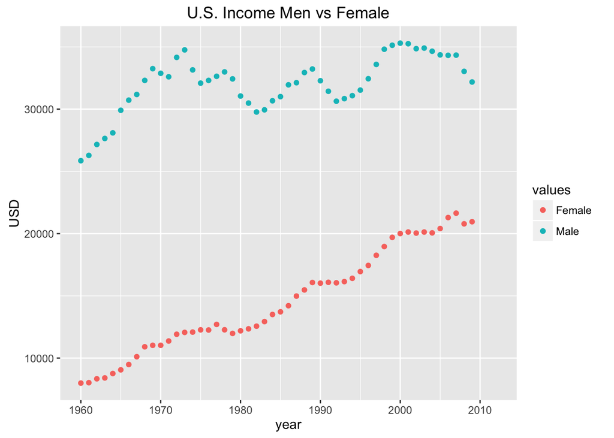

```r
ushousehold%>% ggplot(aes(year1)) + geom_point(aes(y=inc_median_all_male, col="Male")) + geom_point(aes(y=inc_median_all_female, col="Female"))+labs(title="U.S. Income Men vs Female", y = "USD", x= "year", col="values")
```

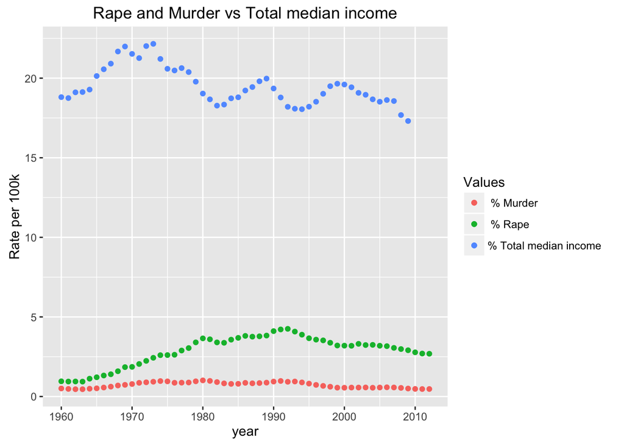

```r
income<-rap_hom%>%mutate(total_income=(inc_median_all_male+inc_median_all_female)/2)%>%mutate(total_incomepct=((inc_median_all_male+inc_median_all_female)/residents*100000))

income%>% ggplot(aes(year1)) + geom_point(aes(y=total_incomepct,  col='% Total median income')) +geom_point(aes(y=murderpct, color = " % Murder"))+ geom_point(aes(y = rapepct,color=" % Rape "))+ labs(title="Rape and Murder vs Total median income", y="Rate per 100k", col="Values", x= "year")
```

```r
#ggplot(income, aes(x=total_income, y=murderpct)) + geom_point( aes(color=year1 , size=residents)) +labs(title="U.S. Murder Trends in total median income", y = "Murder percentage")

#ggplot(income, aes(x=total_income, y=rapepct)) + geom_point( aes(color=year1 , size=residents))+labs(title="U.S. Rape Trends in total median income", y = "Rape percentage")
```